# Final Project

## How Has the National Basketball Association Changed in the Past 40 Years?

### By Nihar Majmudar

National Basketball Association (NBA) players come in all types of skill levels. From the 1st pick in the draft to free agents picked up by teams halfway throughout the season, it is clear that every player provides different value for a team. A big question that has arisen over the past decade is how the style of these players has changed in the NBA of this era compared to the prior eras. Some trends are clear, however some are more hidden. The change in the styles of play from these players have resulted in massive changes to the team aspects of basketball. In this tutorial I hope to show insights on how the game of basketball, has changed in the NBA over the past 40 years. I also want to see if we can predict an era a team played in based on their statistics for a given season. Being able to do this could possibly show what teams in certain eras could be considered "ahead of their time".

```python
import pandas as pd
import requests
import matplotlib.pyplot as plt
from bs4 import BeautifulSoup
from urllib.parse import urlparse
import numpy as np
import seaborn as sns
import statsmodels.formula.api as smf
import sys
!{sys.executable} -m pip install lxml
!{sys.executable} -m pip install html5lib
import html5lib
```

## Data Collection + Parsing

```python
#Acess URL
r = requests.get('https://www.basketball-reference.com/leagues/NBA_stats_per_game.html')
```

```python
#Find table with statistics
root = BeautifulSoup(r.content)
nba_averages = root.find("table")
nba_averages = pd.read_html(r.text, flavor='lxml',header=[1])
nba_averages = nba_averages[0]
nba_averages
```

|  | Rk | Season | Lg | Age | Ht | Wt | G | MP | FG | FGA | ... | PTS | FG% | 3P% | FT% | Pace | eFG% | TOV% | ORB% | FT/FGA | ORtg |
| --- | --- | --- | --- | --- | --- | --- | --- | --- | --- | --- | --- | --- | --- | --- | --- | --- | --- | --- | --- | --- | --- |
| 0 | 1 | 2020-21 | NBA | 26.1 | 6-6 | 217 | 1051 | 241.5 | 41.2 | 88.4 | ... | 112.1 | .466 | .367 | .778 | 99.2 | .538 | 12.4 | 22.2 | .192 | 112.3 |
| 1 | 2 | 2019-20 | NBA | 26.1 | 6-6 | 218 | 1059 | 241.8 | 40.9 | 88.8 | ... | 111.8 | .460 | .358 | .773 | 100.3 | .529 | 12.8 | 22.5 | .201 | 110.6 |
| 2 | 3 | 2018-19 | NBA | 26.3 | 6-6 | 219 | 1230 | 241.6 | 41.1 | 89.2 | ... | 111.2 | .461 | .355 | .766 | 100.0 | .524 | 12.4 | 22.9 | .198 | 110.4 |
| 3 | 4 | 2017-18 | NBA | 26.4 | 6-7 | 220 | 1230 | 241.4 | 39.6 | 86.1 | ... | 106.3 | .460 | .362 | .767 | 97.3 | .521 | 13.0 | 22.3 | .193 | 108.6 |
| 4 | 5 | 2016-17 | NBA | 26.6 | 6-7 | 221 | 1230 | 241.6 | 39.0 | 85.4 | ... | 105.6 | .457 | .358 | .772 | 96.4 | .514 | 12.7 | 23.3 | .209 | 108.8 |
| ... | ... | ... | ... | ... | ... | ... | ... | ... | ... | ... | ... | ... | ... | ... | ... | ... | ... | ... | ... | ... | ... |
| 76 | 71 | 1950-51 | NBA | NaN | NaN | NaN | 354 | NaN | 29.8 | 83.6 | ... | 84.1 | .357 | NaN | .733 | NaN | .357 | NaN | NaN | .293 | NaN |
| 77 | 72 | 1949-50 | NBA | NaN | NaN | NaN | 561 | NaN | 28.2 | 83.1 | ... | 80.0 | .340 | NaN | .714 | NaN | .340 | NaN | NaN | .284 | NaN |
| 78 | 73 | 1948-49 | BAA | NaN | NaN | NaN | 360 | NaN | 29.0 | 88.7 | ... | 80.0 | .327 | NaN | .703 | NaN | .327 | NaN | NaN | .248 | NaN |
| 79 | 74 | 1947-48 | BAA | NaN | NaN | NaN | 192 | NaN | 27.2 | 96.0 | ... | 72.7 | .284 | NaN | .675 | NaN | .284 | NaN | NaN | .190 | NaN |
| 80 | 75 | 1946-47 | BAA | NaN | NaN | NaN | 331 | NaN | 25.9 | 92.9 | ... | 67.8 | .279 | NaN | .641 | NaN | .279 | NaN | NaN | .171 | NaN |

81 rows × 32 columns

```python
#Create empty dataframe
teams = pd.DataFrame()
```

```python
#For all the years since the 3pt line was created, extract every single team's average statistics for those years
for i in range(1980, 2021):
    r = requests.get(f'https://basketball.realgm.com/nba/team-stats/{i}/Averages/Team_Totals/Regular_Season')
    root = BeautifulSoup(r.content)
    ind_teams = root.find("table")
    ind_teams = pd.read_html(r.text, flavor='lxml')
    ind_teams[12]['Year'] = i
    teams = teams.append(ind_teams[12])
teams
```

|  | # | Team | GP | MPG | FGM | FGA | FG% | 3PM | 3PA | 3P% | ... | TOV | PF | ORB | DRB | RPG | APG | SPG | BPG | PPG | Year |
| --- | --- | --- | --- | --- | --- | --- | --- | --- | --- | --- | --- | --- | --- | --- | --- | --- | --- | --- | --- | --- | --- |
| 0 | 1 | San Antonio | 82 | 48.2 | 47.0 | 94.4 | 0.498 | 0.6 | 2.5 | 0.252 | ... | 19.4 | 25.6 | 14.1 | 30.7 | 44.7 | 28.4 | 9.4 | 4.1 | 119.4 | 1980 |
| 1 | 2 | L.A. Lakers | 82 | 48.5 | 47.5 | 89.9 | 0.529 | 0.2 | 1.2 | 0.200 | ... | 20.0 | 21.8 | 13.2 | 32.4 | 45.6 | 29.4 | 9.4 | 6.7 | 115.1 | 1980 |
| 2 | 3 | Cleveland | 82 | 48.6 | 46.5 | 98.1 | 0.474 | 0.4 | 2.3 | 0.193 | ... | 16.7 | 23.6 | 15.9 | 29.0 | 45.0 | 25.7 | 9.3 | 4.2 | 114.1 | 1980 |
| 3 | 4 | New York | 82 | 48.2 | 46.4 | 93.6 | 0.496 | 0.5 | 2.3 | 0.220 | ... | 19.7 | 26.4 | 15.1 | 28.1 | 43.2 | 27.6 | 10.7 | 5.6 | 114.0 | 1980 |
| 4 | 5 | Boston | 82 | 48.5 | 44.1 | 90.1 | 0.490 | 2.0 | 5.1 | 0.384 | ... | 18.8 | 24.1 | 15.0 | 30.0 | 44.9 | 26.8 | 9.9 | 3.8 | 113.5 | 1980 |
| ... | ... | ... | ... | ... | ... | ... | ... | ... | ... | ... | ... | ... | ... | ... | ... | ... | ... | ... | ... | ... | ... |
| 25 | 26 | Cleveland | 65 | 48.4 | 40.3 | 87.9 | 0.458 | 11.2 | 31.8 | 0.351 | ... | 16.5 | 18.3 | 10.8 | 33.4 | 44.2 | 23.1 | 6.9 | 3.2 | 106.9 | 2020 |
| 26 | 27 | Chicago | 65 | 48.2 | 39.6 | 88.6 | 0.447 | 12.2 | 35.1 | 0.348 | ... | 15.5 | 21.8 | 10.5 | 31.4 | 41.9 | 23.2 | 10.0 | 4.1 | 106.8 | 2020 |
| 27 | 28 | Golden State | 65 | 48.4 | 38.6 | 88.1 | 0.438 | 10.4 | 31.3 | 0.334 | ... | 14.9 | 20.1 | 10.0 | 32.9 | 42.8 | 25.6 | 8.2 | 4.6 | 106.3 | 2020 |
| 28 | 29 | New York | 66 | 48.4 | 40.0 | 89.3 | 0.447 | 9.6 | 28.4 | 0.337 | ... | 14.3 | 22.2 | 12.0 | 34.5 | 46.5 | 22.1 | 7.6 | 4.7 | 105.8 | 2020 |
| 29 | 30 | Charlotte | 65 | 48.5 | 37.3 | 85.9 | 0.434 | 12.1 | 34.3 | 0.352 | ... | 14.6 | 18.8 | 11.0 | 31.8 | 42.8 | 23.8 | 6.6 | 4.1 | 102.9 | 2020 |

1134 rows × 23 columns

```python
#Get data from advanced statistics table on the page
teams_adv = pd.DataFrame()
for i in range(1980, 2021):
    x = requests.get(f'https://basketball.realgm.com/nba/team-stats/{i}/Advanced_Stats/Team_Totals/Regular_Season')
    root2 = BeautifulSoup(x.content)
    stats = root2.find("table")
    stats = pd.read_html(x.text, flavor='lxml')
    stats[12]['Year'] = i
    teams_adv = teams_adv.append(stats[12])
teams_adv = teams_adv.drop(['#', 'TS%', 'Total S%', 'ORB%', 'DRB%', 'TRB%', 'AST%', 'TOV%', 'Pace', 'Poss', 'eDiff', 'DRtg', 'FIC40', 'PPS', 'BLK%', 'STL%'], axis=1)
teams_adv
```

|  | Team | eFG% | ORtg | Year |
| --- | --- | --- | --- | --- |
| 0 | Boston | 0.501 | 109.4 | 1980 |
| 1 | L.A. Lakers | 0.530 | 109.5 | 1980 |
| 2 | Seattle | 0.474 | 105.8 | 1980 |
| 3 | Philadelphia | 0.494 | 105.0 | 1980 |
| 4 | Milwaukee | 0.491 | 106.8 | 1980 |
| ... | ... | ... | ... | ... |
| 25 | New York | 0.501 | 106.5 | 2020 |
| 26 | Charlotte | 0.504 | 106.3 | 2020 |
| 27 | Atlanta | 0.515 | 107.2 | 2020 |
| 28 | Cleveland | 0.522 | 107.5 | 2020 |
| 29 | Golden State | 0.497 | 105.2 | 2020 |

1134 rows × 4 columns

```python
#Merge the regular statistics and advanced statistics table
teams = pd.merge(teams, teams_adv, on=["Team", "Year"])
teams
```

|  | # | Team | GP | MPG | FGM | FGA | FG% | 3PM | 3PA | 3P% | ... | ORB | DRB | RPG | APG | SPG | BPG | PPG | Year | eFG% | ORtg |
| --- | --- | --- | --- | --- | --- | --- | --- | --- | --- | --- | --- | --- | --- | --- | --- | --- | --- | --- | --- | --- | --- |
| 0 | 1 | San Antonio | 82 | 48.2 | 47.0 | 94.4 | 0.498 | 0.6 | 2.5 | 0.252 | ... | 14.1 | 30.7 | 44.7 | 28.4 | 9.4 | 4.1 | 119.4 | 1980 | 0.502 | 108.6 |
| 1 | 2 | L.A. Lakers | 82 | 48.5 | 47.5 | 89.9 | 0.529 | 0.2 | 1.2 | 0.200 | ... | 13.2 | 32.4 | 45.6 | 29.4 | 9.4 | 6.7 | 115.1 | 1980 | 0.530 | 109.5 |
| 2 | 3 | Cleveland | 82 | 48.6 | 46.5 | 98.1 | 0.474 | 0.4 | 2.3 | 0.193 | ... | 15.9 | 29.0 | 45.0 | 25.7 | 9.3 | 4.2 | 114.1 | 1980 | 0.476 | 106.7 |
| 3 | 4 | New York | 82 | 48.2 | 46.4 | 93.6 | 0.496 | 0.5 | 2.3 | 0.220 | ... | 15.1 | 28.1 | 43.2 | 27.6 | 10.7 | 5.6 | 114.0 | 1980 | 0.498 | 106.5 |
| 4 | 5 | Boston | 82 | 48.5 | 44.1 | 90.1 | 0.490 | 2.0 | 5.1 | 0.384 | ... | 15.0 | 30.0 | 44.9 | 26.8 | 9.9 | 3.8 | 113.5 | 1980 | 0.501 | 109.4 |
| ... | ... | ... | ... | ... | ... | ... | ... | ... | ... | ... | ... | ... | ... | ... | ... | ... | ... | ... | ... | ... | ... |
| 1129 | 26 | Cleveland | 65 | 48.4 | 40.3 | 87.9 | 0.458 | 11.2 | 31.8 | 0.351 | ... | 10.8 | 33.4 | 44.2 | 23.1 | 6.9 | 3.2 | 106.9 | 2020 | 0.522 | 107.5 |
| 1130 | 27 | Chicago | 65 | 48.2 | 39.6 | 88.6 | 0.447 | 12.2 | 35.1 | 0.348 | ... | 10.5 | 31.4 | 41.9 | 23.2 | 10.0 | 4.1 | 106.8 | 2020 | 0.515 | 106.7 |
| 1131 | 28 | Golden State | 65 | 48.4 | 38.6 | 88.1 | 0.438 | 10.4 | 31.3 | 0.334 | ... | 10.0 | 32.9 | 42.8 | 25.6 | 8.2 | 4.6 | 106.3 | 2020 | 0.497 | 105.2 |
| 1132 | 29 | New York | 66 | 48.4 | 40.0 | 89.3 | 0.447 | 9.6 | 28.4 | 0.337 | ... | 12.0 | 34.5 | 46.5 | 22.1 | 7.6 | 4.7 | 105.8 | 2020 | 0.501 | 106.5 |
| 1133 | 30 | Charlotte | 65 | 48.5 | 37.3 | 85.9 | 0.434 | 12.1 | 34.3 | 0.352 | ... | 11.0 | 31.8 | 42.8 | 23.8 | 6.6 | 4.1 | 102.9 | 2020 | 0.504 | 106.3 |

1134 rows × 25 columns

## Cleaning our Data

The first table I cleaned was the NBA averages over time table. The first thing I did was remove rows that contained labels. I did this because the labels were the same as the labels at the top of the current table, they were just included multiple times on the site I extracted it from. Next I dropped all stats that aren't really the focus of the tutorial. Stats like the Age, Height, Weight, and MP per game for teams aren't really relevant in seeing how the NBA has changed over time because most of these stay very consistent over time. The biggest change was dropping all years before the 3pt line was created. I did this because the addition of a 3pt line marks a transition into the "modern NBA era" (this era is split up into many era in between) as it has now become one of the biggest parts of the game. Comparing the league with the 3pt line to one without it wouldn't be as fruitful and many of the contentious debates focus on the league with a 3pt line. To read more about how the 3pt line changed the game of basketball, read [here](https://www.thehoopsgeek.com/history-three-pointer/).

The next table I didn't have to clean as much because I only collected years from the site after the 3pt line was created.

```python
#Drop label columns
nba_averages = nba_averages.drop(labels=[20,21,42,43, 0, 64, 65], axis=0)
#Drop non-useful statistics
nba_averages = nba_averages.drop(['Lg','Age', 'Ht', 'Wt', 'G', 'MP', 'FT/FGA', 'Rk', 'TOV%', 'Pace', 'FT%', 'DRB', 'ORB', 'ORB%', 'FT', 'TRB', 'BLK'], axis=1)
#Drop all the years that not all stats were collected (takes away all years there was no 3pt line)
nba_averages = nba_averages.dropna()
for i, v in nba_averages.iterrows():
    v['Season'] = int(str(v['Season'])[0:4])+1
nba_averages = nba_averages.sort_values(by=['Season'], ascending=True)
nba_averages
```

|  | Season | FG | FGA | 3P | 3PA | FTA | AST | STL | TOV | PF | PTS | FG% | 3P% | eFG% | ORtg |
| --- | --- | --- | --- | --- | --- | --- | --- | --- | --- | --- | --- | --- | --- | --- | --- |
| 45 | 1980 | 43.6 | 90.6 | 0.8 | 2.8 | 27.8 | 25.8 | 9.4 | 18.9 | 24.4 | 109.3 | .481 | .280 | .486 | 105.3 |
| 44 | 1981 | 43.0 | 88.4 | 0.5 | 2.0 | 28.9 | 25.5 | 9.0 | 18.7 | 25.1 | 108.1 | .486 | .245 | .489 | 105.5 |
| 41 | 1982 | 43.3 | 88.2 | 0.6 | 2.3 | 28.6 | 25.2 | 8.5 | 17.7 | 26.2 | 108.6 | .491 | .262 | .495 | 106.9 |
| 40 | 1983 | 43.5 | 89.7 | 0.5 | 2.3 | 28.3 | 25.9 | 8.9 | 19.1 | 25.6 | 108.5 | .485 | .238 | .488 | 104.7 |
| 39 | 1984 | 43.5 | 88.4 | 0.6 | 2.4 | 29.7 | 26.2 | 8.5 | 17.9 | 25.8 | 110.1 | .492 | .250 | .495 | 107.6 |
| 38 | 1985 | 43.8 | 89.1 | 0.9 | 3.1 | 29.4 | 26.3 | 8.5 | 17.9 | 24.9 | 110.8 | .491 | .282 | .496 | 107.9 |
| 37 | 1986 | 43.2 | 88.6 | 0.9 | 3.3 | 30.3 | 26.0 | 8.8 | 17.8 | 25.2 | 110.2 | .487 | .282 | .493 | 107.2 |
| 36 | 1987 | 42.6 | 88.8 | 1.4 | 4.7 | 30.5 | 26.0 | 8.6 | 17.0 | 24.5 | 109.9 | .480 | .301 | .488 | 108.3 |
| 35 | 1988 | 42.1 | 87.7 | 1.6 | 5.0 | 29.1 | 25.8 | 8.5 | 16.7 | 24.1 | 108.2 | .480 | .316 | .489 | 108.0 |
| 34 | 1989 | 42.5 | 89.0 | 2.1 | 6.6 | 28.8 | 25.6 | 9.1 | 17.2 | 23.7 | 109.2 | .477 | .323 | .489 | 107.8 |
| 33 | 1990 | 41.5 | 87.2 | 2.2 | 6.6 | 28.5 | 24.9 | 8.5 | 16.1 | 23.3 | 107.0 | .476 | .331 | .489 | 108.1 |
| 32 | 1991 | 41.4 | 87.2 | 2.3 | 7.1 | 27.9 | 24.7 | 8.6 | 16.0 | 23.2 | 106.3 | .474 | .320 | .487 | 107.9 |
| 31 | 1992 | 41.3 | 87.3 | 2.5 | 7.6 | 26.7 | 24.5 | 8.6 | 15.6 | 22.2 | 105.3 | .472 | .331 | .487 | 108.2 |
| 30 | 1993 | 40.7 | 86.0 | 3.0 | 9.0 | 27.7 | 24.7 | 8.6 | 15.9 | 23.2 | 105.3 | .473 | .336 | .491 | 108.0 |
| 29 | 1994 | 39.3 | 84.4 | 3.3 | 9.9 | 26.6 | 24.4 | 8.9 | 16.0 | 22.2 | 101.5 | .466 | .333 | .485 | 106.3 |
| 28 | 1995 | 38.0 | 81.5 | 5.5 | 15.3 | 27.1 | 23.4 | 8.3 | 15.9 | 23.5 | 101.4 | .466 | .359 | .500 | 108.3 |
| 27 | 1996 | 37.0 | 80.2 | 5.9 | 16.0 | 26.4 | 22.7 | 8.0 | 15.8 | 23.0 | 99.5 | .462 | .367 | .499 | 107.6 |
| 26 | 1997 | 36.1 | 79.3 | 6.0 | 16.8 | 25.3 | 22.0 | 8.2 | 15.7 | 22.1 | 96.9 | .455 | .360 | .493 | 106.7 |
| 25 | 1998 | 35.9 | 79.7 | 4.4 | 12.7 | 26.3 | 22.0 | 8.4 | 15.5 | 22.4 | 95.6 | .450 | .346 | .478 | 105.0 |
| 24 | 1999 | 34.2 | 78.2 | 4.5 | 13.2 | 25.8 | 20.7 | 8.4 | 15.3 | 22.2 | 91.6 | .437 | .339 | .466 | 102.2 |
| 23 | 2000 | 36.8 | 82.1 | 4.8 | 13.7 | 25.3 | 22.3 | 7.9 | 15.5 | 23.3 | 97.5 | .449 | .353 | .478 | 104.1 |
| 22 | 2001 | 35.7 | 80.6 | 4.8 | 13.7 | 24.9 | 21.8 | 7.8 | 15.0 | 22.3 | 94.8 | .443 | .354 | .473 | 103.0 |
| 19 | 2002 | 36.2 | 81.3 | 5.2 | 14.7 | 23.8 | 21.9 | 7.8 | 14.5 | 21.2 | 95.5 | .445 | .354 | .477 | 104.5 |
| 18 | 2003 | 35.7 | 80.8 | 5.1 | 14.7 | 24.4 | 21.5 | 7.9 | 14.9 | 21.8 | 95.1 | .442 | .349 | .474 | 103.6 |
| 17 | 2004 | 35.0 | 79.8 | 5.2 | 14.9 | 24.2 | 21.3 | 7.9 | 15.0 | 21.4 | 93.4 | .439 | .347 | .471 | 102.9 |
| 16 | 2005 | 35.9 | 80.3 | 5.6 | 15.8 | 26.1 | 21.3 | 7.5 | 14.5 | 22.6 | 97.2 | .447 | .356 | .482 | 106.1 |
| 15 | 2006 | 35.8 | 79.0 | 5.7 | 16.0 | 26.3 | 20.6 | 7.2 | 14.4 | 22.8 | 97.0 | .454 | .358 | .490 | 106.2 |
| 14 | 2007 | 36.5 | 79.7 | 6.1 | 16.9 | 26.1 | 21.3 | 7.2 | 15.1 | 22.2 | 98.7 | .458 | .358 | .496 | 106.5 |
| 13 | 2008 | 37.3 | 81.5 | 6.6 | 18.1 | 24.9 | 21.8 | 7.3 | 14.1 | 21.0 | 99.9 | .457 | .362 | .497 | 107.5 |
| 12 | 2009 | 37.1 | 80.9 | 6.6 | 18.1 | 24.7 | 21.0 | 7.3 | 14.0 | 21.0 | 100.0 | .459 | .367 | .500 | 108.3 |
| 11 | 2010 | 37.7 | 81.7 | 6.4 | 18.1 | 24.5 | 21.2 | 7.2 | 14.2 | 20.9 | 100.4 | .461 | .355 | .501 | 107.6 |
| 10 | 2011 | 37.2 | 81.2 | 6.5 | 18.0 | 24.4 | 21.5 | 7.3 | 14.3 | 20.7 | 99.6 | .459 | .358 | .498 | 107.3 |
| 9 | 2012 | 36.5 | 81.4 | 6.4 | 18.4 | 22.5 | 21.0 | 7.7 | 14.6 | 19.6 | 96.3 | .448 | .349 | .487 | 104.6 |
| 8 | 2013 | 37.1 | 82.0 | 7.2 | 20.0 | 22.2 | 22.1 | 7.8 | 14.6 | 19.8 | 98.1 | .453 | .359 | .496 | 105.8 |
| 7 | 2014 | 37.7 | 83.0 | 7.7 | 21.5 | 23.6 | 22.0 | 7.7 | 14.6 | 20.7 | 101.0 | .454 | .360 | .501 | 106.6 |
| 6 | 2015 | 37.5 | 83.6 | 7.8 | 22.4 | 22.8 | 22.0 | 7.7 | 14.4 | 20.2 | 100.0 | .449 | .350 | .496 | 105.6 |
| 5 | 2016 | 38.2 | 84.6 | 8.5 | 24.1 | 23.4 | 22.3 | 7.8 | 14.4 | 20.3 | 102.7 | .452 | .354 | .502 | 106.4 |
| 4 | 2017 | 39.0 | 85.4 | 9.7 | 27.0 | 23.1 | 22.6 | 7.7 | 14.0 | 19.9 | 105.6 | .457 | .358 | .514 | 108.8 |
| 3 | 2018 | 39.6 | 86.1 | 10.5 | 29.0 | 21.7 | 23.2 | 7.7 | 14.3 | 19.9 | 106.3 | .460 | .362 | .521 | 108.6 |
| 2 | 2019 | 41.1 | 89.2 | 11.4 | 32.0 | 23.1 | 24.6 | 7.6 | 14.1 | 20.9 | 111.2 | .461 | .355 | .524 | 110.4 |
| 1 | 2020 | 40.9 | 88.8 | 12.2 | 34.1 | 23.1 | 24.4 | 7.6 | 14.5 | 20.8 | 111.8 | .460 | .358 | .529 | 110.6 |

```python
teams = teams.reset_index()
```

```python
# Drop statistics that are not useful in our study
# These are statistics that haven't seen much change over time
teams = teams.drop(['#', 'index', 'MPG', 'GP', 'ORB', 'DRB', 'FTM', 'FT%'], axis=1)
teams.rename(columns = {"3PM": "3P", 'FGM': 'FG', 'Year': 'Season', 'APG': 'AST', 'SPG': 'STL', 'PPG': 'PTS'}, inplace = True)
teams
```

|  | Team | FG | FGA | FG% | 3P | 3PA | 3P% | FTA | TOV | PF | RPG | AST | STL | BPG | PTS | Season | eFG% | ORtg |
| --- | --- | --- | --- | --- | --- | --- | --- | --- | --- | --- | --- | --- | --- | --- | --- | --- | --- | --- |
| 0 | San Antonio | 47.0 | 94.4 | 0.498 | 0.6 | 2.5 | 0.252 | 30.8 | 19.4 | 25.6 | 44.7 | 28.4 | 9.4 | 4.1 | 119.4 | 1980 | 0.502 | 108.6 |
| 1 | L.A. Lakers | 47.5 | 89.9 | 0.529 | 0.2 | 1.2 | 0.200 | 25.5 | 20.0 | 21.8 | 45.6 | 29.4 | 9.4 | 6.7 | 115.1 | 1980 | 0.530 | 109.5 |
| 2 | Cleveland | 46.5 | 98.1 | 0.474 | 0.4 | 2.3 | 0.193 | 26.9 | 16.7 | 23.6 | 45.0 | 25.7 | 9.3 | 4.2 | 114.1 | 1980 | 0.476 | 106.7 |
| 3 | New York | 46.4 | 93.6 | 0.496 | 0.5 | 2.3 | 0.220 | 27.7 | 19.7 | 26.4 | 43.2 | 27.6 | 10.7 | 5.6 | 114.0 | 1980 | 0.498 | 106.5 |
| 4 | Boston | 44.1 | 90.1 | 0.490 | 2.0 | 5.1 | 0.384 | 29.9 | 18.8 | 24.1 | 44.9 | 26.8 | 9.9 | 3.8 | 113.5 | 1980 | 0.501 | 109.4 |
| ... | ... | ... | ... | ... | ... | ... | ... | ... | ... | ... | ... | ... | ... | ... | ... | ... | ... | ... |
| 1129 | Cleveland | 40.3 | 87.9 | 0.458 | 11.2 | 31.8 | 0.351 | 19.9 | 16.5 | 18.3 | 44.2 | 23.1 | 6.9 | 3.2 | 106.9 | 2020 | 0.522 | 107.5 |
| 1130 | Chicago | 39.6 | 88.6 | 0.447 | 12.2 | 35.1 | 0.348 | 20.5 | 15.5 | 21.8 | 41.9 | 23.2 | 10.0 | 4.1 | 106.8 | 2020 | 0.515 | 106.7 |
| 1131 | Golden State | 38.6 | 88.1 | 0.438 | 10.4 | 31.3 | 0.334 | 23.2 | 14.9 | 20.1 | 42.8 | 25.6 | 8.2 | 4.6 | 106.3 | 2020 | 0.497 | 105.2 |
| 1132 | New York | 40.0 | 89.3 | 0.447 | 9.6 | 28.4 | 0.337 | 23.5 | 14.3 | 22.2 | 46.5 | 22.1 | 7.6 | 4.7 | 105.8 | 2020 | 0.501 | 106.5 |
| 1133 | Charlotte | 37.3 | 85.9 | 0.434 | 12.1 | 34.3 | 0.352 | 21.6 | 14.6 | 18.8 | 42.8 | 23.8 | 6.6 | 4.1 | 102.9 | 2020 | 0.504 | 106.3 |

1134 rows × 18 columns

## Before we start...

Let's talk about what all the stats we will be using mean. It is important to remember that all the stats we are looking at are per game averages (whether for all NBA teams in the "nba_averages" or specific NBA teams in the "teams" table)

3PA - The amount of 3 pointers a team shoots  
3P - The amount of 3 pointers a team makes  
FG- The amount of Field Goals made (includes 3 pointers)  
FGA - Amount of Field Goals attempted (includes 3 pointers)  
AST - Amount of assists(an assist occurs when a player passes to someone on their team and they make a shot because of that pass)  
STL - Amount of steals (a steal is when a team takes possession of the ball from the other team). A higher number is better, it indicates better defensive play from a team.  
TOV - Amount of turnovers (turnover occurs when a team loses possession of the ball for reasons other than shooting). A lower number is better, as it means teams are being more careful with the ball.  
PF - Amount of personal fouls a team commits  
PTS - Amount of points scored  
FG% - Field Goal Percetnage = FG/FGA (higher percentage is better)  
3P% - 3 point percentagev = 3P/3PA (higher percentage is better)  
eFG% - Efficent field goal percentage adjusts for the fact that every 3 point attempt is worth more than a 2 point attempt (higher percentage is better)  
ORtg - Points produced per 100 possessions (higher number is better)

If interested, you can find more about these statistics [here](https://www.breakthroughbasketball.com/stats/definitions.html).

```python
for i in nba_averages.columns:
    nba_averages[i] = nba_averages[i].apply(float)
```

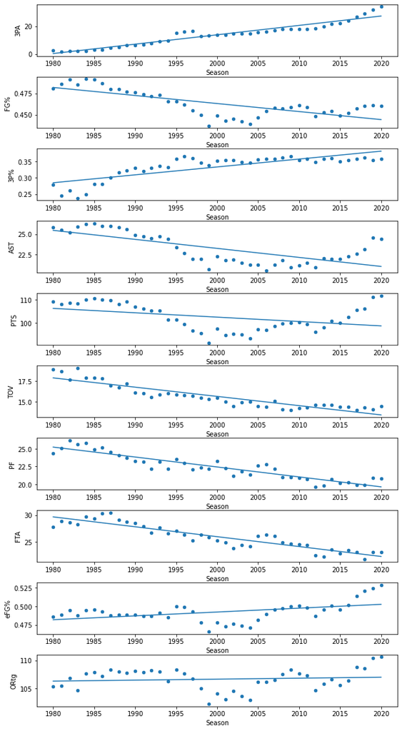

```python
#Plotting all of the stats over time
fig, ax = plt.subplots(10, figsize=(10,20))
fig.subplots_adjust(hspace=.4)
stats = ['3PA', 'FG%', '3P%', 'AST', 'PTS', 'TOV', 'PF', 'FTA', 'eFG%', 'ORtg' ]
counter = 0
for i in range(len(stats)):
    nba_averages.plot(kind='scatter', x='Season', y=stats[i], ax=ax[i])
    trend = np.poly1d(np.polyfit(x = nba_averages['Season'].values.astype(float), y = nba_averages[stats[i]].values.astype(float), deg = 1))
    ax[i].plot(nba_averages['Season'].values, trend(nba_averages['Season'].values))
```

# Observing these key statistics

When looking at these NBA averages over time, it's important to find what they mean in relation to how the game is played and how the game has changed

I decided to look at some key metrics over time such as average 3 point shot attempts per game, FG%, 3 point %, Assists per game, points per game, turnovers per game, and personal fouls per game. Let's see what we can trends we can try and conclude from this preliminary look at our nba averages data.

## Finding Relationships Between Stats

Now that we can see general trends for important statistics over time, I want to find out how certain statistics increases over time affect other statistics. For example, I gave potential correlations between free throw attempts and 3 point shooting, FG% over time and the increase in 3 point attempts, etc. Let's see how well these statistics actually correlate.

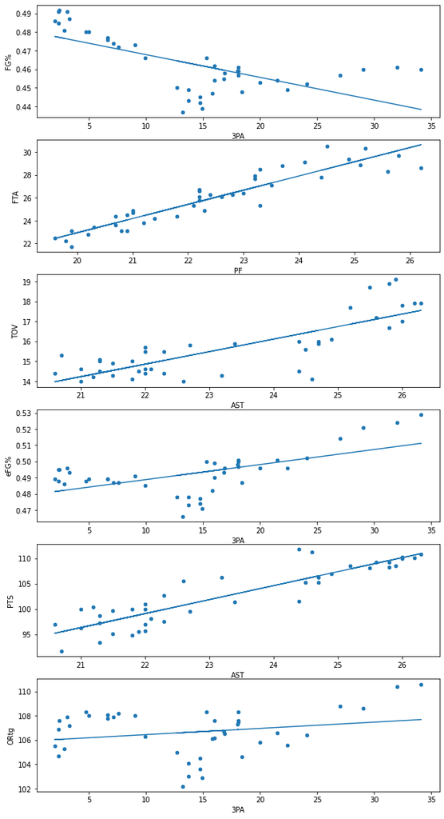

```python
fig, ax = plt.subplots(6, figsize=(10,20))
#See correlation between 3PA and Field Goal Percentage
nba_averages.plot(kind='scatter', x='3PA', y='FG%', ax=ax[0])
trend = np.poly1d(np.polyfit(x = nba_averages['3PA'].values.astype(float), y = nba_averages['FG%'].values.astype(float), deg = 1))
ax[0].plot(nba_averages['3PA'].values, trend(nba_averages['3PA'].values))


nba_averages.plot(kind='scatter', x='PF', y='FTA', ax=ax[1])
trend = np.poly1d(np.polyfit(x = nba_averages['PF'].values.astype(float), y = nba_averages['FTA'].values.astype(float), deg = 1))
ax[1].plot(nba_averages['PF'].values, trend(nba_averages['PF'].values))

nba_averages.plot(kind='scatter', x='AST', y='TOV', ax=ax[2])
trend = np.poly1d(np.polyfit(x = nba_averages['AST'].values.astype(float), y = nba_averages['TOV'].values.astype(float), deg = 1))
ax[2].plot(nba_averages['AST'].values, trend(nba_averages['AST'].values))

nba_averages.plot(kind='scatter', x='3PA', y='eFG%', ax=ax[3])
trend = np.poly1d(np.polyfit(x = nba_averages['3PA'].values.astype(float), y = nba_averages['eFG%'].values.astype(float), deg = 1))
ax[3].plot(nba_averages['3PA'].values, trend(nba_averages['3PA'].values))

nba_averages.plot(kind='scatter', x='AST', y='PTS', ax=ax[4])
trend = np.poly1d(np.polyfit(x = nba_averages['AST'].values.astype(float), y = nba_averages['PTS'].values.astype(float), deg = 1))
ax[4].plot(nba_averages['AST'].values, trend(nba_averages['AST'].values))

nba_averages.plot(kind='scatter', x='3PA', y='ORtg', ax=ax[5])
trend = np.poly1d(np.polyfit(x = nba_averages['3PA'].values.astype(float), y = nba_averages['ORtg'].values.astype(float), deg = 1))
ax[5].plot(nba_averages['3PA'].values, trend(nba_averages['3PA'].values))
```

## Insights between stat correlation

FG% vs 3PA - From this plot we can see that generally, as the amount of 3 point attempts has increased, the average field goal percentage has fallen. This will bring up an interesting observation when we compare it to eFG% vs 3PA.

FTA vs PF - This plot shows what we expect, that as Personal Fouls increase, the amount of Free Throws increase. However, something interesting to note is that PF has and FTA have decreased over time, however points don't reflect this drop in free throw attempts. The amount of points is starting to rise again.

TOV vs AST - This plot shows that as assists have increased, the amount of turnovers has also increased. Since both of these statistics have decreased over time, one observation we can make is that the NBA might be heading towards a less team-oriented, and more isolation like game.

eFG% vs 3PA - This plot has a very interesting takeaway. We saw that FG% has decreased as 3PA, but effective field goal percentage actually increased as 3 point attempts have increased. The reason this is so important is that effective field goal % accounts for the fact that every 3 pointer is worth more than a 2 pointer, meaning that those shots are more valuable. It shows "the percentage a 2 pointer shooter would have to shoot to match the output of a player that also shoots 3". The eFG% is rising to above 50% recently which is higher than any season's FG%. This shows that 3 point shooting is actually more efficient for teams in terms of point output.

## Let's see if there's any other interesting correlations that could show us something

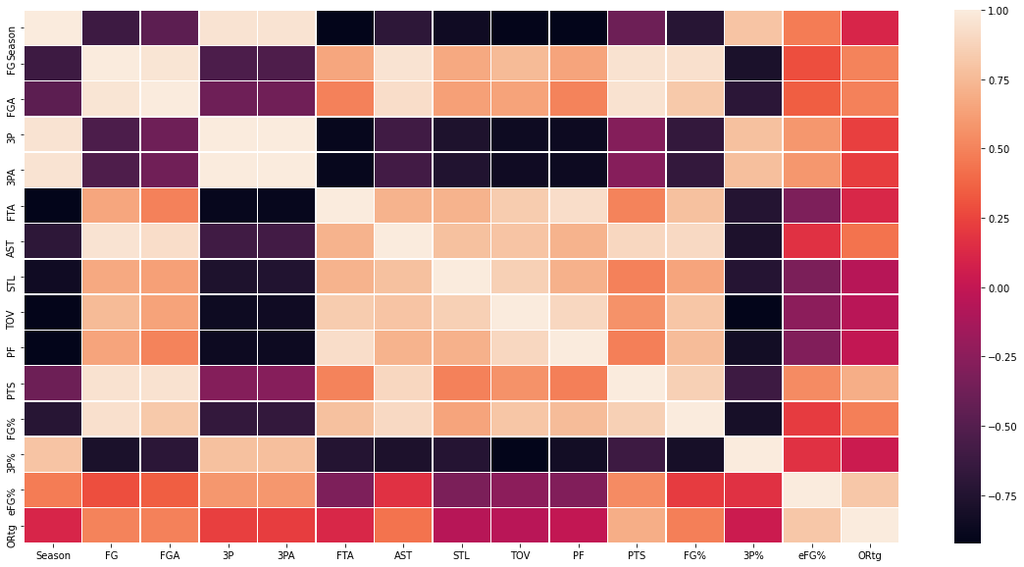

```python
plt.subplots(figsize = (20,10))
sns.heatmap(nba_averages.corr(),fmt = '.1g', linewidths=.5)
```

We saw most of the interesting correlations above from our scatter plots. Although there are some interesting correlations shown in this heatmap, we must think of what actually shows a change in the way the game is played and also consider that correlation does not imply causation.

One item that adds on to the point made about eFG% vs 3PA is that a team's eFG% has a high correlation with their Offensive Rating. An offensive rating measures the amount of points scored per 100 possessions, so team's obviously want to maximize this. Since this is positevly correlated with eFG%, this means teams are also trying to maximize their eFG%, which in turn shows why they are shooting more 3 pointers in today's game.

One last interesting observation is the Field Goal % is positively correlated with the amount of assists in a game, however eFG% has almost no correlation with assists. This is not to say involving your teammates in a game is worse or better, it is just an interesting point to make because if we only looked at FG% we would wonder why there are less assists in today's game compared to the past.

## Hypothesis Testing

In my hypothesis testing I want to test the correlation between a couple of variables.

eFG% vs 3PA

Significance Level - .05  
H0 - No relationship between efficient field goal percentage and 3 point attempts per game  
Ha - There is a linearity between efficient field goal percentage and 3 point attempts per game

```python
reg = smf.ols("Q('eFG%') ~ Q('3PA')", data = nba_averages).fit()
reg.summary()
```

OLS Regression Results

| Dep. Variable: | Q('eFG%') | R-squared: | 0.345 |
| --- | --- | --- | --- |
| Model: | OLS | Adj. R-squared: | 0.328 |
| Method: | Least Squares | F-statistic: | 20.52 |
| Date: | Sat, 15 May 2021 | Prob (F-statistic): | 5.46e-05 |
| Time: | 04:51:21 | Log-Likelihood: | 128.20 |
| No. Observations: | 41 | AIC: | -252.4 |
| Df Residuals: | 39 | BIC: | -249.0 |
| Df Model: | 1 |  |  |
| Covariance Type: | nonrobust |  |  |

|  | coef | std err | t | P>\|t\| | [0.025 | 0.975] |
| --- | --- | --- | --- | --- | --- | --- |
| Intercept | 0.4795 | 0.003 | 144.675 | 0.000 | 0.473 | 0.486 |
| Q('3PA') | 0.0009 | 0.000 | 4.530 | 0.000 | 0.001 | 0.001 |

| Omnibus: | 3.417 | Durbin-Watson: | 0.315 |
| --- | --- | --- | --- |
| Prob(Omnibus): | 0.181 | Jarque-Bera (JB): | 3.042 |
| Skew: | -0.660 | Prob(JB): | 0.218 |
| Kurtosis: | 2.801 | Cond. No. | 31.7 |

Notes:  
[1] Standard Errors assume that the covariance matrix of the errors is correctly specified.

TOV vs AST

Significance Level - .05  
H0 - No relationship between Turnovers and Assists per game  
Ha - There is a linearity between Turnovers and Assists per game

```python
reg = smf.ols("Q('TOV') ~ Q('AST')", data = nba_averages).fit()
reg.summary()
```

OLS Regression Results

| Dep. Variable: | Q('TOV') | R-squared: | 0.647 |
| --- | --- | --- | --- |
| Model: | OLS | Adj. R-squared: | 0.638 |
| Method: | Least Squares | F-statistic: | 71.53 |
| Date: | Sat, 15 May 2021 | Prob (F-statistic): | 2.35e-10 |
| Time: | 04:51:21 | Log-Likelihood: | -52.122 |
| No. Observations: | 41 | AIC: | 108.2 |
| Df Residuals: | 39 | BIC: | 111.7 |
| Df Model: | 1 |  |  |
| Covariance Type: | nonrobust |  |  |

|  | coef | std err | t | P>\|t\| | [0.025 | 0.975] |
| --- | --- | --- | --- | --- | --- | --- |
| Intercept | 1.0449 | 1.733 | 0.603 | 0.550 | -2.460 | 4.549 |
| Q('AST') | 0.6277 | 0.074 | 8.457 | 0.000 | 0.478 | 0.778 |

| Omnibus: | 1.956 | Durbin-Watson: | 0.415 |
| --- | --- | --- | --- |
| Prob(Omnibus): | 0.376 | Jarque-Bera (JB): | 0.994 |
| Skew: | -0.261 | Prob(JB): | 0.608 |
| Kurtosis: | 3.556 | Cond. No. | 293. |

Notes:  
[1] Standard Errors assume that the covariance matrix of the errors is correctly specified.

ORtg vs eFG%

Significance Level - .05  
H0 - No relationship between Offensive Rating and efficient field goal %  
Ha - There is a linearity between Offensive Rating and efficient field goal %

```python
reg = smf.ols("Q('ORtg') ~ Q('eFG%')", data = nba_averages).fit()
reg.summary()
```

OLS Regression Results

| Dep. Variable: | Q('ORtg') | R-squared: | 0.668 |
| --- | --- | --- | --- |
| Model: | OLS | Adj. R-squared: | 0.660 |
| Method: | Least Squares | F-statistic: | 78.57 |
| Date: | Sat, 15 May 2021 | Prob (F-statistic): | 6.94e-11 |
| Time: | 04:51:21 | Log-Likelihood: | -61.745 |
| No. Observations: | 41 | AIC: | 127.5 |
| Df Residuals: | 39 | BIC: | 130.9 |
| Df Model: | 1 |  |  |
| Covariance Type: | nonrobust |  |  |

|  | coef | std err | t | P>\|t\| | [0.025 | 0.975] |
| --- | --- | --- | --- | --- | --- | --- |
| Intercept | 48.4808 | 6.564 | 7.385 | 0.000 | 35.203 | 61.759 |
| Q('eFG%') | 118.1173 | 13.326 | 8.864 | 0.000 | 91.164 | 145.071 |

| Omnibus: | 3.226 | Durbin-Watson: | 0.583 |
| --- | --- | --- | --- |
| Prob(Omnibus): | 0.199 | Jarque-Bera (JB): | 2.389 |
| Skew: | 0.434 | Prob(JB): | 0.303 |
| Kurtosis: | 2.196 | Cond. No. | 94.8 |

Notes:  
[1] Standard Errors assume that the covariance matrix of the errors is correctly specified.

## Insights from Hypothesis Testing

For all of the test we ran above, the p-values were all very close to 0. This, combined with the heatmap plotted above proves a correlation between these variables because the p-values are lower than our chosen significance level of .05.

## Machine Learning

Now that we can make some generalizations about how the NBA has shifted over time I wanted to see if I could classify NBA teams based on their statistics to predict what year they played in. The reason I am using a decision tree classifier is because there a certain bins of "Seasons" and we are trying to predict given a team's statistics, which bin they fit into.

After my terrible results in my first Decision Tree attempt, I wanted to see if we can try and classify team's into eras to see if certain era's had statistics that specifically reflected that era.

To learn more about how decision tree classifiers operate check out this [link](https://www.datacamp.com/community/tutorials/decision-tree-classification-python)!

```python
from sklearn.tree import DecisionTreeClassifier
from sklearn.model_selection import train_test_split
from sklearn.metrics import accuracy_score
X = teams[['FG', 'FGA', 'FG%', '3P', '3PA', '3P%', 'FTA', 'TOV', 'PF', 'RPG', 'AST', 'STL', 'BPG', 'PTS', 'eFG%', 'ORtg']]
y = teams[['Season']]

for i in range(10):
    X_train, X_test, y_train, y_test = train_test_split(X, y, test_size=0.1, random_state = 42)

    dtree_classifier = DecisionTreeClassifier()
    dtree_classifier.fit(X_train, y_train)
    predictions = dtree_classifier.predict(X_test)
    print(accuracy_score(y_test, predictions))
```

```
0.10526315789473684
0.13157894736842105
0.08771929824561403
0.12280701754385964
0.12280701754385964
0.14035087719298245
0.10526315789473684
0.11403508771929824
0.14912280701754385
0.09649122807017543
```

## Interesting Observations + Reasoning Behind Extremely Low Accuracy

Initially looking at my decision tree classifier, I thought that if we got a representative sample of teams from different eras, we would be able to see how teams in certain eras performed and this could then be generalized between all eras.

The biggest flaw in my thinking is that certain variables included in this tree didn't really change much over time AND my mistake in realizing that all NBA teams perform differently every year. For example, if you are a terrible NBA team in a certain year and had poor statistics across the board, since we were studying such a wide range of stats, you might get classified into a team of a different year. Instead, there were a few amounts of statistics that HEAVILY changed over time while some statistics didn't really show a trend over time. Looking back at our regression above we could see that we found some statistics that showed trends over time.

## Improvement to our Decision Tree

Now, we will focus on the statistics that were more representative of changes over time in the NBA. In addition to this, we will try and classify the NBA into era's. For now we'll classify the era's as decades starting from the 80's and going to the 10's (which we'll include 2020 in just for simplicity sake). I will split this into 2 sections where one section tries the same decision tree with a more representative set of statistics and the other combines the previous with the era classification style.

The statistics we saw a clear trend in over time include:  
3PA  
TOV  
PF  
eFG%  
FTA  
AST

Let's first try a decision tree with the same dataset and these new statistics

```python
#Limit use of statistics to those that showed significant change over time
teams_spec = teams[['3PA','FTA','TOV', 'PF', 'eFG%', 'AST', 'ORtg', 'Season']]
X = teams[['3PA','FTA','TOV', 'PF', 'eFG%', 'AST']]
y = teams_spec['Season']
for i in range(10):
    X_train, X_test, y_train, y_test = train_test_split(X, y, test_size=0.1, random_state = 42)
    dtree_classifier = DecisionTreeClassifier()
    dtree_classifier.fit(X_train, y_train)
    predictions = dtree_classifier.predict(X_test)
    print(accuracy_score(y_test, predictions))
```

```
0.08771929824561403
0.12280701754385964
0.17543859649122806
0.17543859649122806
0.16666666666666666
0.14035087719298245
0.14035087719298245
0.15789473684210525
0.16666666666666666
0.16666666666666666
```

## Observations

The reasoning behind the continued low accuracy is that between years that are close to one another, the game's statistics don't change much. What we initially set out to do was see if we can find trends over time and classify a team into a certain "time period" or "era" of play, so now we will make the "bins" for our decision tree into a wider range of dates.

## Next Classification Step

Now we will organize the seasons in our table into certain era's. I will split it by decade as this provides a decent indicator of a split between years.

```python
#Categorize the era's each team played in by sorting by years
def f(row):
    if row['Season'] >= 1980 and row['Season'] < 1990:
        val = 1980
    elif row['Season'] >= 1990 and row['Season'] < 2000:
        val = 1990
    elif  row['Season'] >= 2000 and row['Season'] < 2010:
        val = 2000
    elif row['Season'] >= 2010:
        val = 2010
    return val
teams_spec['Bin'] = teams_spec.apply(f, axis=1)
X = teams[['3PA','FTA','TOV', 'eFG%']]
y = teams_spec['Bin']
for i in range(10):
    X_train, X_test, y_train, y_test = train_test_split(X, y, test_size=0.1, random_state = 42)
    dtree_classifier = DecisionTreeClassifier()
    dtree_classifier.fit(X_train, y_train)
    predictions = dtree_classifier.predict(X_test)
    print(accuracy_score(y_test, predictions))
```

```
0.7105263157894737
0.7456140350877193
0.7192982456140351
0.7017543859649122
0.7192982456140351
0.7105263157894737
0.7017543859649122
0.7105263157894737
0.7105263157894737
0.7105263157894737
```

## Reflection on Decision Tree

As we saw from our new decision tree, our accuracy score is still pretty bad. At the end of the day this can be attributed to the volatility of NBA teams based on how they performed in a particular season. For example, teams that perform particularly bad in a season such as 2018, might seem like they belong as an average team in a 2010 season. The reason it is so hard to counteract this is because only certain statistics change greatly over time, but there's still similarities in a lot of other statistics. It was easy to see general trends of play, but when predicting what are a team played in, especially when there are transition periods between eras, make it hard to classify these teams into seasons.

## Show Reasoning Behind Difficulty

This violin plot will show why creating a decision tree with much higher accuracy than the one we made is difficult

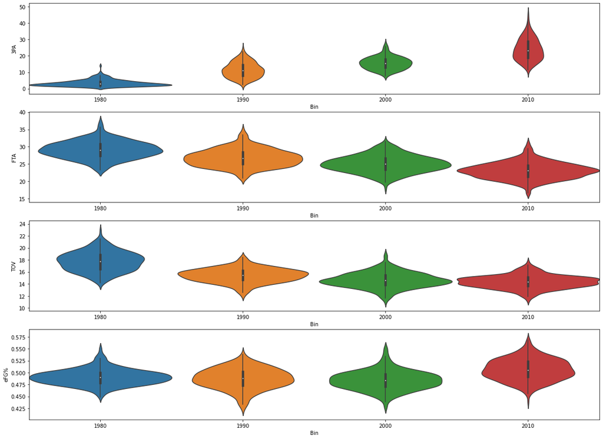

```python
#Categorize the era's each team played in by sorting by years
def f(row):
    if row['Season'] >= 1980 and row['Season'] < 1990:
        val = 1980
    elif row['Season'] >= 1990 and row['Season'] < 2000:
        val = 1990
    elif  row['Season'] >= 2000 and row['Season'] < 2010:
        val = 2000
    elif row['Season'] >= 2010:
        val = 2010
    return val
teams_spec['Bin'] = teams_spec.apply(f, axis=1)
fig, ax = plt.subplots(4, figsize=(20,15))
sns.violinplot(x='Bin', y='3PA', width=1, data=teams_spec, ax=ax[0])
sns.violinplot(x='Bin', y='FTA', width=1, data=teams_spec, ax=ax[1])
sns.violinplot(x='Bin', y='TOV', width=1, data=teams_spec, ax=ax[2])
sns.violinplot(x='Bin', y='eFG%', width=1, data=teams_spec, ax=ax[3])
```

These violin plots show some reasoning behind why predicting the Era a team played in is so hard. Seeing that there are many teams in these distributions that fit the averages of past "Bins" that we've created can show why a decision tree is difficult to make with the stats we are using. To generate a better decision tree in the future, we will probably need to use more advanced statistics or find statistics that have more clearly changed over time, like the 3PA statistic.

## Final Thoughts

Throughout this tutorial I attempted to show how the game of basketball has changed in the National Basketball Association (NBA) over time and if we could categorize teams based on the era's they played in. We found a lot of interesting changes in statistics and the way the game was played. Specifically, we saw the great increase in 3-point shot attempts and 3-point shooting percentage along with slight increases in Offensive Rating and efficient field goalt percentage. We saw declines in fouls, turnovers, and free throw attempts.

Finally, we set out to see if we could categorize and NBA team on what era they played in based on these statistics. Our final decision tree showed an accuracy rating hovering around 71%. This isn't a great accuracy score by any means showing just how volatile statistics can be in the NBA for certain teams.

If I was able to extend this project/tutorial, I would look into how to better define time periods to match with era's given by experts (these era's aren't specific and are still not well-defined in the NBA community). I would also try and see how accuracy improves when we get rid of outliers in our data, which consist of teams that overperformed greatly for their time period, or teams that were terrible in certain years. I would also try and collect more advanced stats and see if they had any correlation with the big statistic changes we saw over time.

I hope you learned a thing or two from this tutorial!